# Tidyverse Exercise

Philipp Umek

22/03/2021

## Tidyverse

- Load packages
  - we need tidyverse

```r
library(tidyverse)
```

## Section 1: Data description

### read csv data

We will read the file “data/covid_us_county.csv.gz”

```r
data_covid <- read_csv("data/covid_us_county.csv.gz")
```

### Simple discription of the table

Now the data is in R workspace. Do the following

### Count the number of variabes and rows

```r
dim(data_covid)
```

```
## [1] 1412820       9
```

### Print out the first 6 rows of the data.frame

```r
head(data_covid, 6)
```

```
## # A tibble: 6 x 9
##    fips county  state     lat  long date       cases state_code deaths
##   <dbl> <chr>   <chr>   <dbl> <dbl> <date>     <dbl> <chr>       <dbl>
## 1  1001 Autauga Alabama  32.5 -86.6 2020-01-22     0 AL              0
## 2  1001 Autauga Alabama  32.5 -86.6 2020-01-23     0 AL              0
## 3  1001 Autauga Alabama  32.5 -86.6 2020-01-24     0 AL              0
## 4  1001 Autauga Alabama  32.5 -86.6 2020-01-25     0 AL              0
## 5  1001 Autauga Alabama  32.5 -86.6 2020-01-26     0 AL              0
## 6  1001 Autauga Alabama  32.5 -86.6 2020-01-27     0 AL              0
```

### How many states exists?

(Hint: use `count()`)

```r
length(unique(data_covid$state))
```

```
## [1] 58
```

```r
# or
data_covid %>% group_by(state) %>% count()
```

```
## # A tibble: 58 x 2
## # Groups:   state [58]
##    state                n
##    <chr>            <int>
##  1 Alabama          29187
##  2 Alaska           13113
##  3 American Samoa     423
##  4 Arizona           7191
##  5 Arkansas         32571
##  6 California       25380
##  7 Colorado         27918
##  8 Connecticut       4230
##  9 Delaware          2115
## 10 Diamond Princess   423
## # … with 48 more rows
```

## Data wrangling, Part 1

### Erase unnecessary rows

First remove the non-county(sic!) entries

```r
table(is.na(data_covid$county))
```

```
##
##   FALSE    TRUE
## 1410282    2538
```

```r
data_covid <- data_covid %>% filter(!is.na(county))
```

### Create a subset dataset

Find the latest date of the data, then subset the data with only the newest date for each country

```r
dat2 <- data_covid %>% filter(date == max(date))
```

### Max cases/deaths

Which county has the highest number of cases/deaths? What is the number?

```r
dat2 %>% group_by(county, state) %>% summarize(deaths = max(deaths)) %>% arrange(desc(deaths)) %>% head(5)
```

```
## # A tibble: 5 x 3
## # Groups:   county [5]
##   county      state      deaths
##   <chr>       <chr>       <dbl>
## 1 Los Angeles California  22722
## 2 Cook        Illinois     9546
## 3 Maricopa    Arizona      9512
## 4 Kings       New York     9473
## 5 Queens      New York     9115
```

```r
dat2 %>% group_by(county, state) %>% summarize(cases = max(cases)) %>% arrange(desc(cases)) %>% head(10)
```

```
## # A tibble: 10 x 3
## # Groups:   county [10]
##    county         state        cases
##    <chr>          <chr>        <dbl>
##  1 Los Angeles    California 1213288
##  2 Maricopa       Arizona     520919
##  3 Cook           Illinois    486730
##  4 Miami-Dade     Florida     432177
##  5 Harris         Texas       368908
##  6 Riverside      California  292967
##  7 San Bernardino California  289405
##  8 Dallas         Texas       287989
##  9 San Diego      California  267177
## 10 Orange         California  264478
```

## Data wrangling, Part 2

### First recorded cases/deaths (by county)

Find the 10 counties with the earliest recorded cases/deaths.

```r
data_covid %>% filter(cases > 0) %>% group_by(state, county) %>% arrange(desc(state, county, date)) %>% slice(1) %>% arrange(date) %>% select(county, state, date, cases) %>% head(10)
```

```
## # A tibble: 10 x 4
## # Groups:   state, county [10]
##    county      state         date       cases
##    <chr>       <chr>         <date>     <dbl>
##  1 King        Washington    2020-01-22     1
##  2 Cook        Illinois      2020-01-24     1
##  3 Maricopa    Arizona       2020-01-26     1
##  4 Los Angeles California    2020-01-26     1
##  5 Orange      California    2020-01-26     1
##  6 Suffolk     Massachusetts 2020-01-29     1
##  7 Santa Clara California    2020-01-31     1
##  8 San Benito  California    2020-02-03     2
##  9 Worcester   Massachusetts 2020-02-06     1
## 10 San Diego   California    2020-02-11     1
```

```r
data_covid %>% filter(deaths > 0) %>% group_by(state, county) %>% arrange(desc(state, county, date)) %>% slice(1) %>% arrange(date) %>% select(county, state, date, deaths) %>% head(10)
```

```
## # A tibble: 10 x 4
## # Groups:   state, county [10]
##    county      state      date       deaths
##    <chr>       <chr>      <date>      <dbl>
##  1 King        Washington 2020-02-29      1
##  2 Snohomish   Washington 2020-03-02      1
##  3 Placer      California 2020-03-04      1
##  4 Lee         Florida    2020-03-08      1
##  5 Santa Rosa  Florida    2020-03-08      1
##  6 Grant       Washington 2020-03-09      1
##  7 Santa Clara California 2020-03-10      1
##  8 Bergen      New Jersey 2020-03-10      1
##  9 Los Angeles California 2020-03-11      1
## 10 Sacramento  California 2020-03-11      1
```

### Aggregate the number of death

For each state, calculate the total number of cases/deaths for each day (Hint: grouping and summarize)

```r
data_covid %>% group_by(state, date) %>% summarise(cases = sum(cases),
                                                   deaths = sum(deaths))
```

```
## # A tibble: 21,996 x 4
## # Groups:   state [52]
##    state   date       cases deaths
##    <chr>   <date>     <dbl>  <dbl>
##  1 Alabama 2020-01-22     0      0
##  2 Alabama 2020-01-23     0      0
##  3 Alabama 2020-01-24     0      0
##  4 Alabama 2020-01-25     0      0
##  5 Alabama 2020-01-26     0      0
##  6 Alabama 2020-01-27     0      0
##  7 Alabama 2020-01-28     0      0
##  8 Alabama 2020-01-29     0      0
##  9 Alabama 2020-01-30     0      0
## 10 Alabama 2020-01-31     0      0
## # … with 21,986 more rows
```

### First recorded cases/deaths (by state)

Find the earliest day when a state recorded a case. Arrange by the date in descending order

```r
data_covid %>% filter(cases > 0) %>% group_by(state) %>% summarise(date = min(date)) %>% arrange(desc(date))
```

```
## # A tibble: 52 x 2
##    state                date
##    <chr>                <date>
##  1 West Virginia        2020-03-18
##  2 District of Columbia 2020-03-16
##  3 Puerto Rico          2020-03-16
##  4 Alaska               2020-03-13
##  5 Arkansas             2020-03-13
##  6 Idaho                2020-03-13
##  7 Montana              2020-03-13
##  8 Maine                2020-03-12
##  9 Mississippi          2020-03-12
## 10 North Dakota         2020-03-12
## # … with 42 more rows
```

## Visualizing (Optional)

Now let’s visualize the outputs using ggplot

### Time series plot of total cases/death in the US

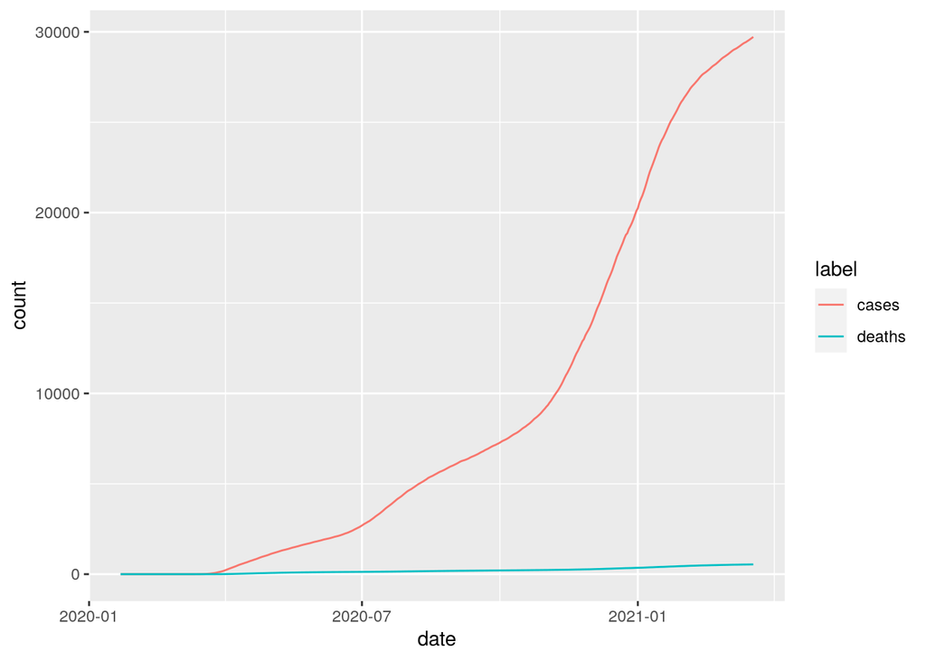

```r
data_covid %>% group_by(date) %>% summarise(cases = sum(cases), deaths = sum(deaths)) %>% mutate(cases = cases / 1000, deaths = deaths / 1000) %>% pivot_longer(-date, names_to = "label", values_to = "count") %>%
  ggplot(aes(x = date, y = count, group = label, color = label)) + geom_line()
```

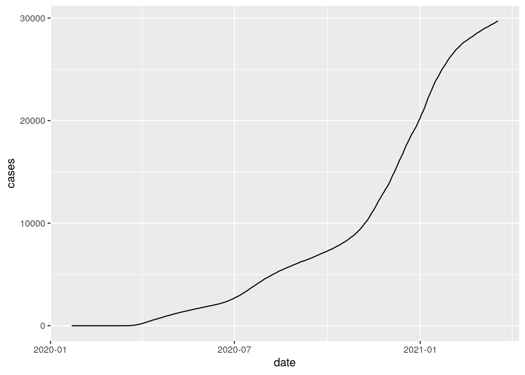

```r
data_covid %>% group_by(date) %>% summarise(cases = sum(cases)) %>% mutate(cases = cases / 1000) %>% ggplot(aes(x = date, y = cases)) + geom_line()
```

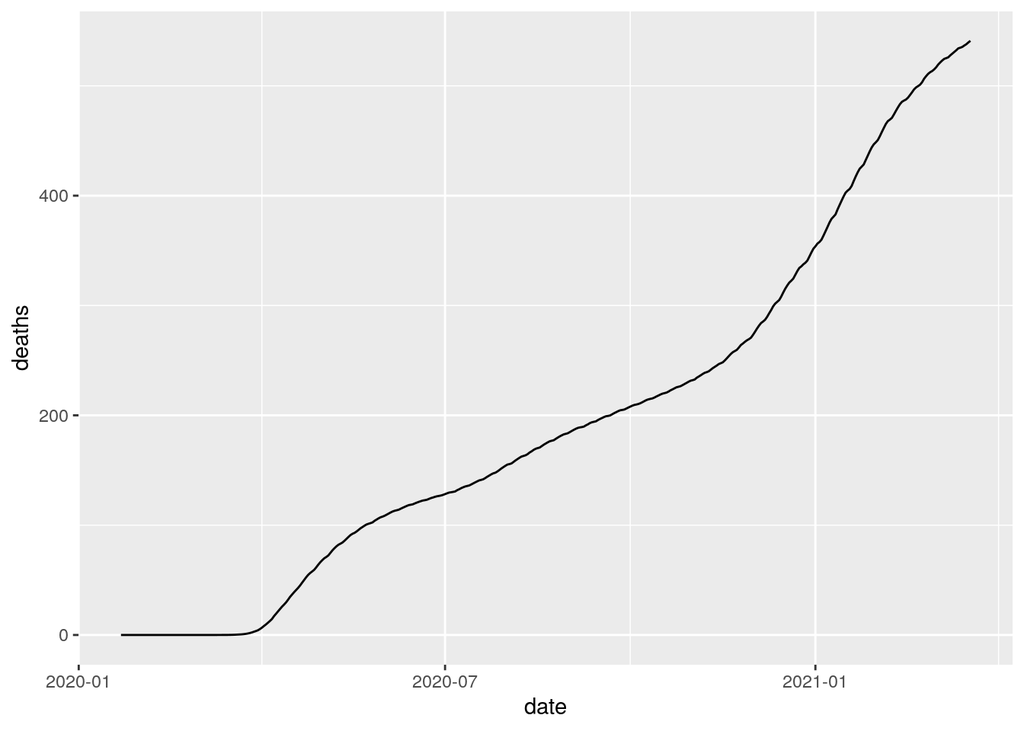

```r
data_covid %>% group_by(date) %>% summarise(deaths = sum(deaths)) %>% mutate(deaths = deaths / 1000) %>% ggplot(aes(x = date, y = deaths)) + geom_line()
```

### Time series plot of total cases/deaths by the state

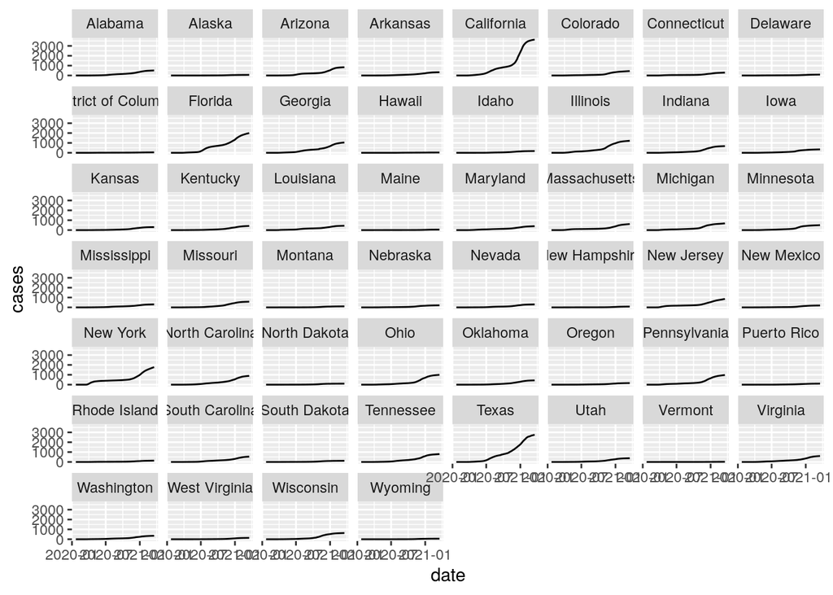

```r
data_covid %>% group_by(state, date) %>% summarise(cases = sum(cases)) %>% mutate(cases = cases / 1000) %>% ggplot(aes(x = date, y = cases)) + geom_line() + facet_wrap(~ state)
```

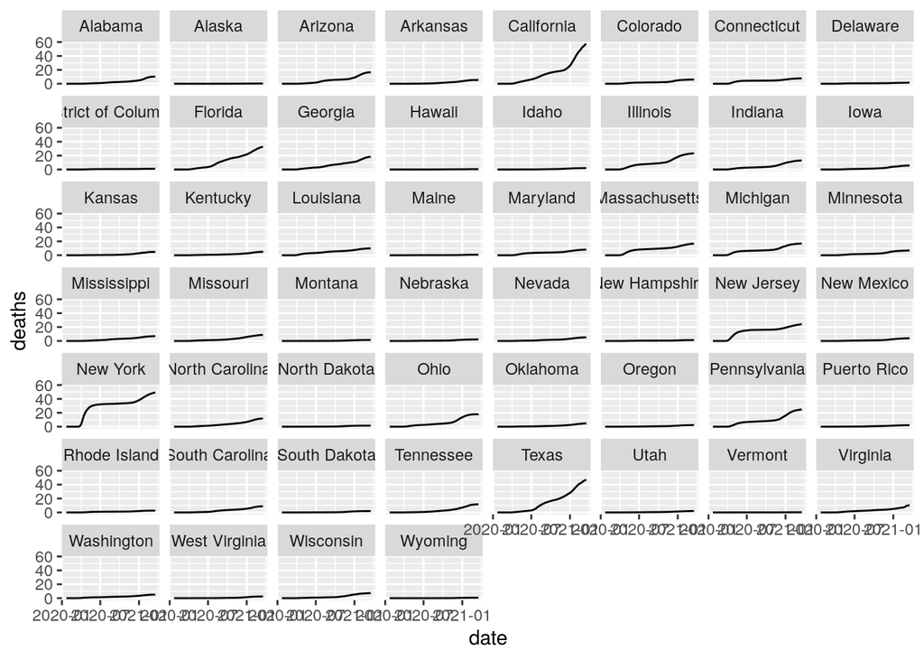

```r
data_covid %>% group_by(state, date) %>% summarise(deaths = sum(deaths)) %>% mutate(deaths = deaths / 1000) %>% ggplot(aes(x = date, y = deaths)) + geom_line() + facet_wrap(~ state)
```

### Time series plot of total cases/deaths by the state per 100,000 inhabitants

```r
library(usa)
```

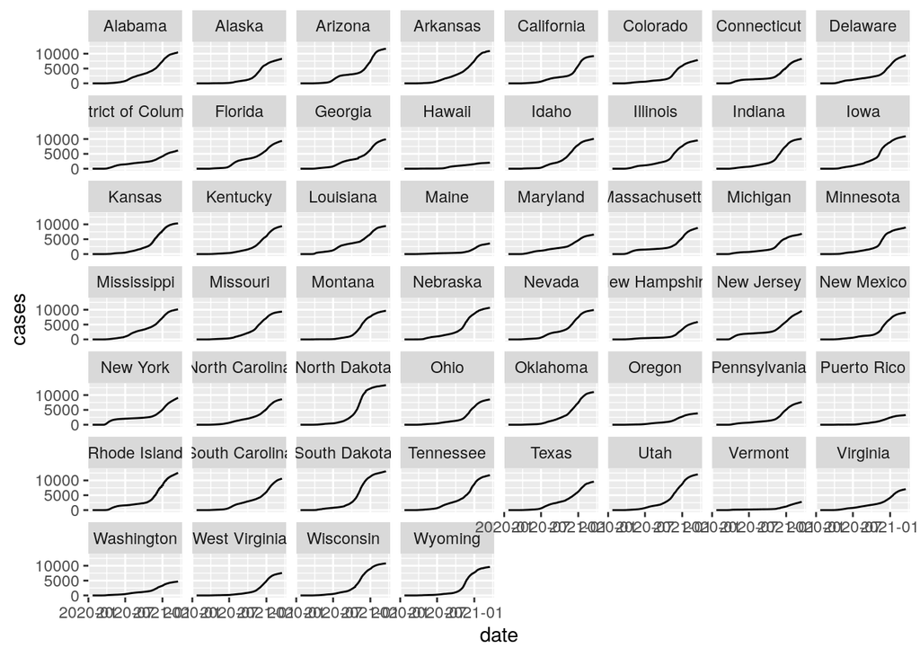

```r
usapop <- usa::facts %>% select(state = name, population)
dat2 <- merge(x = data_covid, y = usapop, all.x = TRUE, by = "state")

dat2 %>% group_by(state, date, population) %>% summarise(cases = sum(cases)) %>% mutate(cases = cases / (population / 100000)) %>% ggplot(aes(x = date, y = cases)) + geom_line() + facet_wrap(~ state)
```

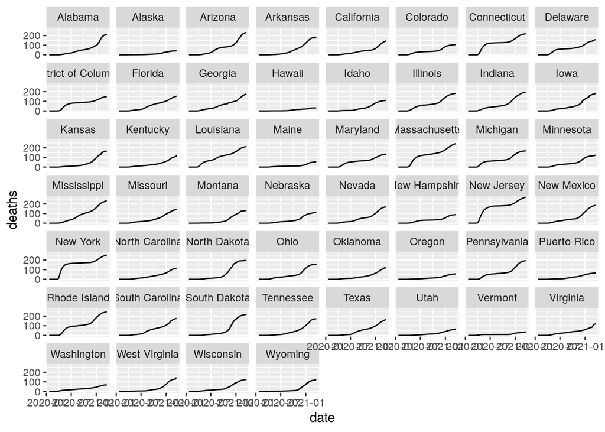

```r
dat2 %>% group_by(state, date, population) %>% summarise(deaths = sum(deaths)) %>% mutate(deaths = deaths / (population / 100000)) %>% ggplot(aes(x = date, y = deaths)) + geom_line() + facet_wrap(~ state)
```

### Daily increase trend

How’s the trend of the daily case increases. Which state look bad now?

Top 10 of states with most new cases in the last 7 days

```r
dat2 %>% group_by(state, date) %>% summarise(cases = sum(cases)) %>% mutate(trend = cases - lag(cases)) %>% filter(date >= max(date)-7) %>% group_by(state) %>% summarise(trend = sum(trend)) %>% arrange(desc(trend)) %>% head(10)
```

```
## # A tibble: 10 x 2
##    state          trend
##    <chr>          <dbl>
##  1 New York       52168
##  2 Florida        36606
##  3 Texas          33631
##  4 New Jersey     31107
##  5 California     22874
##  6 Michigan       22674
##  7 Pennsylvania   22017
##  8 Illinois       14064
##  9 Massachusetts  13408
## 10 North Carolina 13404
```

Top 10 of states with most new cases in the last 7 days in relation to population

```r
dat2 %>% group_by(state, population, date) %>% arrange(date) %>% summarise(cases = sum(cases)) %>% mutate(trend = cases - lag(cases)) %>% filter(date >= max(date)-7) %>% group_by(state, population) %>% summarise(increase_total = sum(trend)) %>% mutate(increase_per_10k = round(increase_total / (population / 10000), 1)) %>% arrange(desc(increase_per_10k)) %>% head(10)
```

```
## # A tibble: 10 x 4
## # Groups:   state [10]
##    state          population increase_total increase_per_10k
##    <chr>               <dbl>          <dbl>            <dbl>
##  1 New Jersey        8908520          31107             34.9
##  2 Rhode Island      1057315           2919             27.6
##  3 New York         19542209          52168             26.7
##  4 Michigan          9995915          22674             22.7
##  5 Connecticut       3572665           7299             20.4
##  6 Delaware           967171           1955             20.2
##  7 Massachusetts     6902149          13408             19.4
##  8 South Carolina    5084127           9409             18.5
##  9 Florida          21299325          36606             17.2
## 10 Pennsylvania     12807060          22017             17.2
```